# Tugas Simple Regression

Anak Agung Ayu Diva Shanty Darmawan

1/31/2022

Berikut adalah data-data yang akan digunakan.

```r
library(ggplot2)
mfc = read.csv('MFC.csv', stringsAsFactors = FALSE)
sp500 = read.csv('sp500.csv', stringsAsFactors = FALSE)
irx = read.csv('irx.csv', stringsAsFactors = FALSE)
```

# Jawaban nomor 1

Buatlah data frame baru yang berisi dua variabel, excess return individual dari saham Manulife dan excess return market S&P500 mulai dari Januari 2005 sampai Desember 2014.

Untuk mendapatkan excess return dapat menggunakan model CPAM.

```r
index = seq(from = 127, to= 8, by = -1)
mfcreturn = (mfc$Adj.Close[index]/mfc$Adj.Close[index + 1])- 1
spreturn = (sp500$Adj.Close[index]/sp500$Adj.Close[index + 1]) - 1
rf_rate = irx$Adj.Close[index + 1]/1200
ROR_mfc = mfcreturn - rf_rate
ROR_sp = spreturn - rf_rate
data_10 = data.frame(individu = ROR_mfc, market = ROR_sp)
head(data_10)
```

```
##       individu       market
## 1  0.062016836  0.016885013
## 2  0.030516898 -0.021359322
## 3 -0.045465272 -0.022376915
## 4  0.006420319  0.027587880
## 5  0.038077092 -0.002544381
## 6  0.049531119  0.033418287
```

Buatlah scatterplot dari data tersebut.

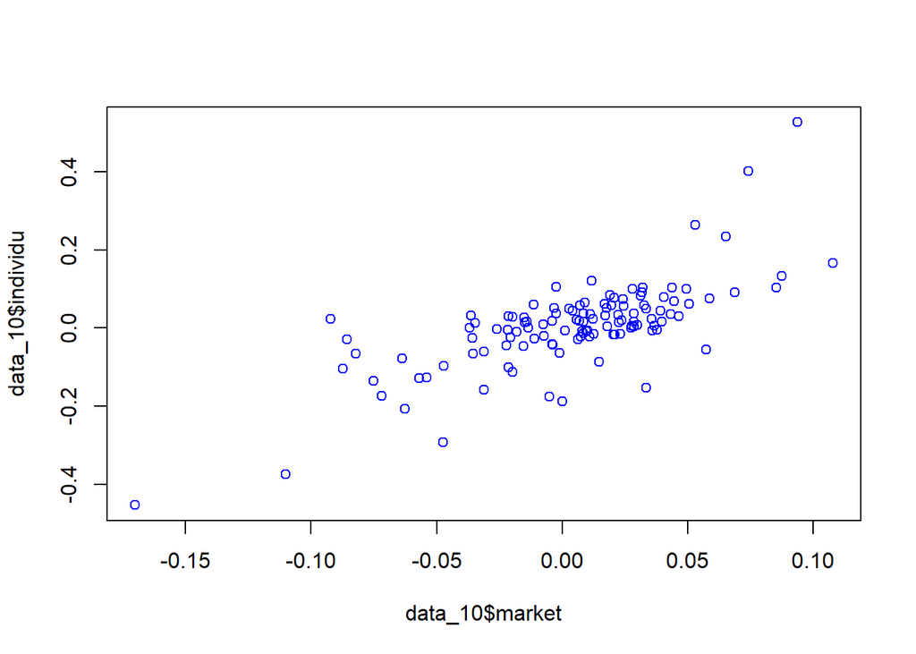

```r
plot(data_10$market, data_10$individu, col = "blue")
```

# Jawaban nomor 2

Buatlah data training dan data testing dari data pada nomor 1.

```r
n.training = seq(from = 128, to = 21, by = -1)
n.testing = seq(from = 20, to = 9, by = -1)

training.key = sample(nrow(mfc), size = n.training, replace = FALSE, prob = NULL)
testing.key = sample(nrow(mfc), size = n.testing, replace = FALSE, prob = NULL)

training_data = mfc[training.key,]
testing_data = mfc[-testing.key,]
```

Buatlah model regresi.

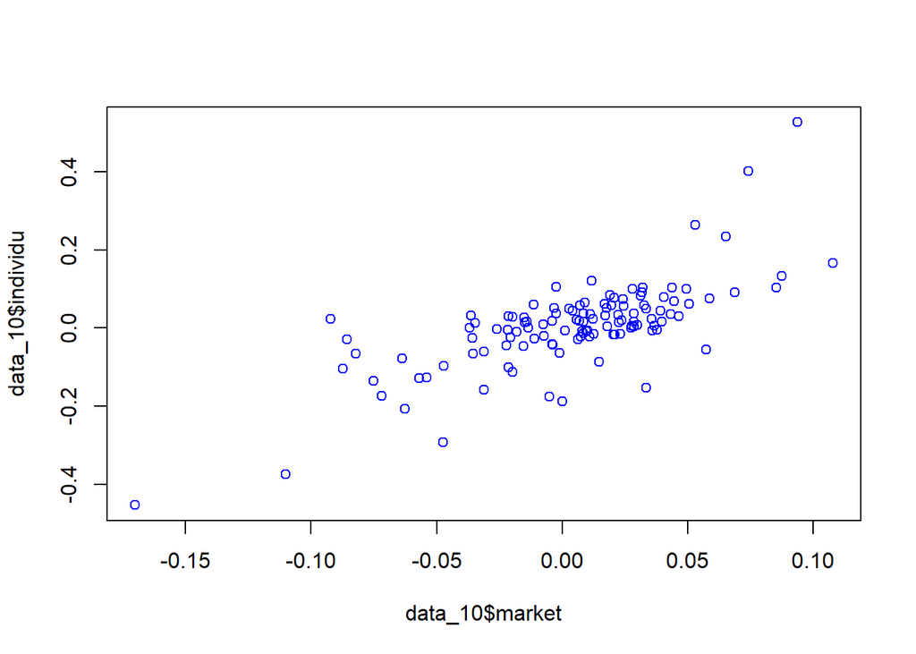

```r
regresi1 = lm(data_10$individu ~ data_10$market, data = data_10)
plot(data_10$market, data_10$individu, col = "blue")
```

Lakukan prediksi.

```r
summary(regresi1)
```

```
##
## Call:
## lm(formula = data_10$individu ~ data_10$market, data = data_10)
##
## Residuals:
##      Min       1Q   Median       3Q      Max
## -0.21652 -0.04091 -0.00232  0.04084  0.34572
##
## Coefficients:
##                 Estimate Std. Error t value Pr(>|t|)
## (Intercept)    -0.002436   0.007262  -0.335    0.738
## data_10$market  1.955416   0.170676  11.457   <2e-16 ***
## ---
## Signif. codes:  0 '***' 0.001 '**' 0.01 '*' 0.05 '.' 0.1 ' ' 1
##
## Residual standard error: 0.07917 on 118 degrees of freedom
## Multiple R-squared:  0.5266, Adjusted R-squared:  0.5226
## F-statistic: 131.3 on 1 and 118 DF,  p-value: < 2.2e-16
```

```r
prediksi = predict(regresi1, newdata = testing_data)
data_10$Predicted = prediksi
View(data_10)
```

# Jawaban nomor 3

Buatlah data frame baru dengan tiga variabe;: excess return Manulife, excess return S&P500, dan variabel kategorikal data yang diambil sebelum 1 September 2008 (BEFORE) dan sesudah (AFTER).

```r
index2 = seq(from = 187, to= 2, by = -1)
mfcreturn_2 = (mfc$Adj.Close[index2]/mfc$Adj.Close[index2 + 1])- 1
spreturn_2 = (sp500$Adj.Close[index2]/sp500$Adj.Close[index2 + 1]) - 1
rf_rate2 = irx$Adj.Close[index2 + 1]/1200
ROR_mfc_2 = mfcreturn_2 - rf_rate2
ROR_sp_2 = spreturn_2 - rf_rate2
tgl = mfc$Date[index2 + 1]
data2_10 = data.frame(tgl, ROR_mfc_2, ROR_sp_2)

tgl_2 = ("2008-09-01")
tgl_baru = as.Date(tgl_2)
data2_10$tgl = as.Date(data2_10$tgl)

for(i in 1:nrow(data2_10)){
  if(data2_10$tgl[i] < tgl_baru){
    data2_10$status[i] = "Before"
  }
  else{
    data2_10$status[i] = "After"
  }
}

View(data2_10)
```

Scatterplot dari data tersebut.

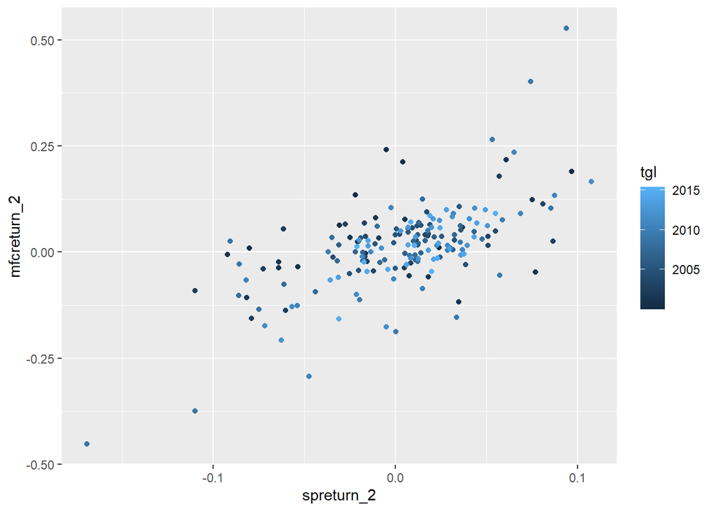

```r
ggplot(data = data2_10) + geom_point(mapping = aes(x = spreturn_2, y = mfcreturn_2, color = tgl))
```

# Jawaban nomor 4

Buatlah dua model CPAM dengan model yang menggunakan data sebelum 1 September 2008 dan menggunakan data sesudah 1 September 2008.

```r
index3 = seq(from = 104, to= 1, by = -1)
mfcreturn_3 = (mfc$Adj.Close[index3]/mfc$Adj.Close[index3 + 1])- 1
spreturn_3 = (sp500$Adj.Close[index3]/sp500$Adj.Close[index3 + 1]) - 1
rf_rate3 = irx$Adj.Close[index3 + 1]/1200
ROR_mfc_3 = mfcreturn_3 - rf_rate3
ROR_sp_3 = spreturn_3 - rf_rate3
data3_10 = data.frame(individu = ROR_mfc_3, market = ROR_sp_3)
head(data3_10)
```

```
##       individu       market
## 1 -0.006438452  0.009988209
## 2 -0.003361005 -0.025992009
## 3  0.022051448  0.005817483
## 4  0.044106564  0.039211524
## 5  0.036506383  0.028611729
## 6 -0.004895672 -0.021641322
```

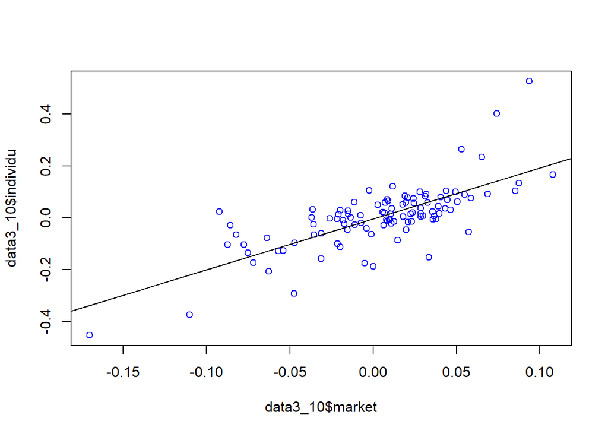

```r
regresi2 = lm(data3_10$individu~data3_10$market, data = data3_10)
plot(data3_10$market, data3_10$individu, col = "blue")
abline(regresi2)
```

```r
index4 = seq(from = 186, to= 105, by = -1)
mfcreturn_4 = (mfc$Adj.Close[index4]/mfc$Adj.Close[index4 + 1])- 1
spreturn_4 = (sp500$Adj.Close[index4]/sp500$Adj.Close[index4 + 1]) - 1
rf_rate4 = irx$Adj.Close[index4 + 1]/1200
ROR_mfc_4 = mfcreturn_4 - rf_rate4
ROR_sp_4 = spreturn_4 - rf_rate4
data4_10 = data.frame(individu = ROR_mfc_4, market = ROR_sp_4)
head(data4_10)
```

```
##       individu      market
## 1  0.184583238  0.09201983
## 2  0.059063188 -0.03556242
## 3  0.130016075 -0.02662338
## 4  0.006063222  0.01935855
## 5 -0.008258805 -0.02109128
## 6  0.212617698  0.05568244
```

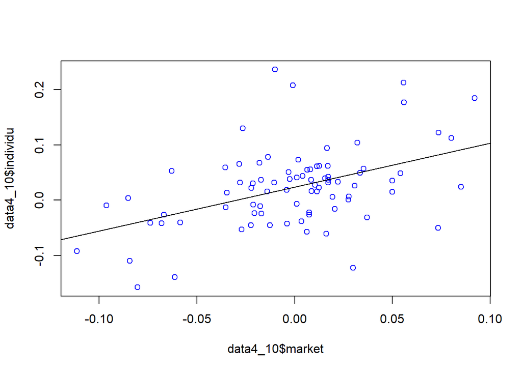

```r
regresi3 = lm(data4_10$individu~data4_10$market, data = data4_10)
plot(data4_10$market, data4_10$individu, col = "blue")
abline(regresi3)
```

# Jawaban nomor 5

Dari ketiga model, buatlah kesimpulan model manakah yang terbaik.

```r
summary(regresi1)
```

```
##
## Call:
## lm(formula = data_10$individu ~ data_10$market, data = data_10)
##
## Residuals:
##      Min       1Q   Median       3Q      Max
## -0.21652 -0.04091 -0.00232  0.04084  0.34572
##
## Coefficients:
##                 Estimate Std. Error t value Pr(>|t|)
## (Intercept)    -0.002436   0.007262  -0.335    0.738
## data_10$market  1.955416   0.170676  11.457   <2e-16 ***
## ---
## Signif. codes:  0 '***' 0.001 '**' 0.01 '*' 0.05 '.' 0.1 ' ' 1
##
## Residual standard error: 0.07917 on 118 degrees of freedom
## Multiple R-squared:  0.5266, Adjusted R-squared:  0.5226
## F-statistic: 131.3 on 1 and 118 DF,  p-value: < 2.2e-16
```

```r
summary(regresi2)
```

```
##
## Call:
## lm(formula = data3_10$individu ~ data3_10$market, data = data3_10)
##
## Residuals:
##      Min       1Q   Median       3Q      Max
## -0.21502 -0.04155 -0.00134  0.04765  0.34681
##
## Coefficients:
##                  Estimate Std. Error t value Pr(>|t|)
## (Intercept)     -0.004165   0.008257  -0.504    0.615
## data3_10$market  1.962257   0.179842  10.911   <2e-16 ***
## ---
## Signif. codes:  0 '***' 0.001 '**' 0.01 '*' 0.05 '.' 0.1 ' ' 1
##
## Residual standard error: 0.08397 on 102 degrees of freedom
## Multiple R-squared:  0.5386, Adjusted R-squared:  0.534
## F-statistic:   119 on 1 and 102 DF,  p-value: < 2.2e-16
```

```r
summary(regresi3)
```

```
##
## Call:
## lm(formula = data4_10$individu ~ data4_10$market, data = data4_10)
##
## Residuals:
##       Min        1Q    Median        3Q       Max
## -0.169251 -0.034006 -0.001101  0.027900  0.220094
##
## Coefficients:
##                 Estimate Std. Error t value Pr(>|t|)
## (Intercept)     0.023732   0.007104   3.341  0.00127 **
## data4_10$market 0.790732   0.172605   4.581 1.68e-05 ***
## ---
## Signif. codes:  0 '***' 0.001 '**' 0.01 '*' 0.05 '.' 0.1 ' ' 1
##
## Residual standard error: 0.0643 on 80 degrees of freedom
## Multiple R-squared:  0.2078, Adjusted R-squared:  0.1979
## F-statistic: 20.99 on 1 and 80 DF,  p-value: 1.678e-05
```

Menurut saya model yang paling bagus adalah model regresi2 karena model tersebut cukup baik dan dapat dikatakan normal dengan median yang hampir 0 serta mean dan max yang sesuai. Selain itu R squared nya juga lebih tinggi dibandingkan 2 model lainnya yaitu 0.534.